# Solutions to Applied Predictive Modeling (Kuhn and Johnson, 2013)

Chapter 7 - Exercise 7.5

by Brian Hassett

# Introduction

This notebook outlines a solution to the exercise using the `tidymodels` package to implement the modeling. I have decided to implement two models, MARS and SVM with polynomial kernel.

# Exercise Instructions

*Instructions adapted from Kuhn and Johnson (2013)[^1].*

Exercise 6.3 describes data for a chemical manufacturing process. Use the same data imputation, data splitting, and pre-processing steps as before and train several nonlinear regression models.

1. Which nonlinear regression model gives the optimal resampling and test set performance?
2. Which predictors are most important in the optimal nonlinear regression model? Do either the biological or process variables dominate the list? How do the top ten important predictors compare to the top ten predictors from the optimal linear model?
3. Explore the relationships between the top predictors and the response for the predictors that are unique to the optimal nonlinear regression model. Do these plots reveal intuition about the biological or process predictors and their relationship with yield?

# Loading Data and EDA

The data set is called `ChemicalManufacturingProcess.RData`. All of the data (predictors and response) is in a data frame also called `ChemicalManufacturingProcess`:

```r
data(ChemicalManufacturingProcess) # name is slightly different from text
ChemicalManufacturingProcess
```

|  | Yield | BiologicalMaterial01 | BiologicalMaterial02 | BiologicalMaterial03 | BiologicalMaterial04 | BiologicalMaterial05 | BiologicalMaterial06 | BiologicalMaterial07 | BiologicalMaterial08 | BiologicalMaterial09 | BiologicalMaterial10 | BiologicalMaterial11 | BiologicalMaterial12 | ManufacturingProcess01 | ManufacturingProcess02 | ManufacturingProcess03 | ManufacturingProcess04 | ManufacturingProcess05 | ManufacturingProcess06 | ManufacturingProcess07 | ManufacturingProcess08 | ManufacturingProcess09 | ManufacturingProcess10 | ManufacturingProcess11 | ManufacturingProcess12 | ManufacturingProcess13 | ManufacturingProcess14 | ManufacturingProcess15 | ManufacturingProcess16 | … |
| --- | --- | --- | --- | --- | --- | --- | --- | --- | --- | --- | --- | --- | --- | --- | --- | --- | --- | --- | --- | --- | --- | --- | --- | --- | --- | --- | --- | --- | --- | --- |
| 1 | 38.00 | 6.25 | 49.58 | 56.97 | 12.74 | 19.51 | 43.73 | 100.0 | 16.66 | 11.44 | 3.46 | 138.1 | 18.83 | NA | NA | NA | NA | NA | NA | NA | NA | 43.00 | NA | NA | NA | 35.5 | 4898 | 6108 | 4682 | … |
| 2 | 42.44 | 8.01 | 60.97 | 67.48 | 14.65 | 19.36 | 53.14 | 100.0 | 19.04 | 12.55 | 3.46 | 153.7 | 21.05 | 0.0 | 0.0 | NA | 917 | 1032.2 | 210.0 | 177 | 178 | 46.57 | NA | NA | 0 | 34.0 | 4869 | 6095 | 4617 | … |
| 3 | 42.03 | 8.01 | 60.97 | 67.48 | 14.65 | 19.36 | 53.14 | 100.0 | 19.04 | 12.55 | 3.46 | 153.7 | 21.05 | 0.0 | 0.0 | NA | 912 | 1003.6 | 207.1 | 178 | 178 | 45.07 | NA | NA | 0 | 34.8 | 4878 | 6087 | 4617 | … |
| 4 | 41.42 | 8.01 | 60.97 | 67.48 | 14.65 | 19.36 | 53.14 | 100.0 | 19.04 | 12.55 | 3.46 | 153.7 | 21.05 | 0.0 | 0.0 | NA | 911 | 1014.6 | 213.3 | 177 | 177 | 44.92 | NA | NA | 0 | 34.8 | 4897 | 6102 | 4635 | … |
| 5 | 42.49 | 7.47 | 63.33 | 72.25 | 14.02 | 17.91 | 54.66 | 100.0 | 18.22 | 12.80 | 3.05 | 147.6 | 21.05 | 10.7 | 0.0 | NA | 918 | 1027.5 | 205.7 | 178 | 178 | 44.96 | NA | NA | 0 | 34.6 | 4992 | 6233 | 4733 | … |
| 6 | 43.57 | 6.12 | 58.36 | 65.31 | 15.17 | 21.79 | 51.23 | 100.0 | 18.30 | 12.13 | 3.78 | 151.9 | 20.76 | 12.0 | 0.0 | NA | 924 | 1016.8 | 208.9 | 178 | 178 | 45.32 | NA | NA | 0 | 34.0 | 4985 | 6222 | 4786 | … |
| 7 | 43.12 | 7.48 | 64.47 | 72.41 | 13.82 | 17.71 | 54.45 | 100.0 | 18.72 | 12.95 | 3.04 | 147.1 | 20.75 | 11.5 | 0.0 | 1.56 | 933 | 988.9 | 210.0 | 177 | 178 | 49.36 | 11.6 | 11.5 | 0 | 32.4 | 4745 | 5999 | 4486 | … |
| 8 | 43.06 | 6.94 | 63.60 | 72.06 | 15.70 | 19.42 | 54.72 | 100.0 | 18.85 | 13.13 | 3.85 | 154.2 | 21.45 | 12.0 | 0.0 | 1.55 | 929 | 1010.9 | 211.7 | 178 | 178 | 48.68 | 10.2 | 11.3 | 0 | 33.6 | 4854 | 6105 | 4626 | … |
| 9 | 41.49 | 6.94 | 63.60 | 72.06 | 15.70 | 19.42 | 54.72 | 100.0 | 18.85 | 13.13 | 3.85 | 154.2 | 21.45 | 12.0 | 0.0 | 1.56 | 928 | 1003.5 | 208.7 | 177 | 177 | 47.20 | 9.7 | 11.1 | 0 | 33.9 | 4893 | 6144 | 4658 | … |
| 10 | 42.45 | 6.94 | 63.60 | 72.06 | 15.70 | 19.42 | 54.72 | 100.0 | 18.85 | 13.13 | 3.85 | 154.2 | 21.45 | 12.0 | 0.0 | 1.55 | 938 | 1003.8 | 209.8 | 177 | 177 | 47.11 | 10.1 | 10.2 | 0 | 34.3 | 4846 | 6077 | 4614 | … |

[output cut: 166 more lines]

## Data Summary

```r
df1 <- ChemicalManufacturingProcess
bh_print_data_summary(df1)
```

```
                      [,1]
num_rows              "    176"
num_cols              "     58"
num_categorical_cols  "      0"
num_numeric_cols      "     58"
all_missing_cols      "      0"
complete_cols         "     30"
total_missing         "    106"
total_percent_missing "      1"
total_data_points     " 10,102"
size_bytes            "101,856"
```

## Distribution of Response Variable

The below plot shows the distribution of the response. It is fairly symmetric and does not need transformation prior to analysis:

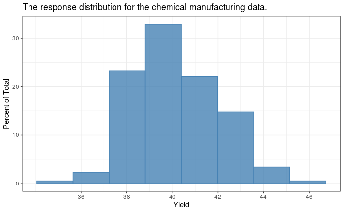

```r
ggplot(df1) +
  geom_histogram(aes(Yield, y = 100*stat(count / sum(count))), bins = 8,
                 fill = "steelblue", color = "steelblue", alpha = 0.8) + # Ref: https://stackoverflow.com/a/51850864
  scale_x_continuous(breaks = seq(36, 46, by = 2)) +
  labs(x = "Yield", y = "Percent of Total",
       title = "The response distribution for the chemical manufacturing data.")
```

## Histograms of Predictors

Some of the predictors appear skewed. A Box-Cox transformation will be applied as part of data preprocessing.

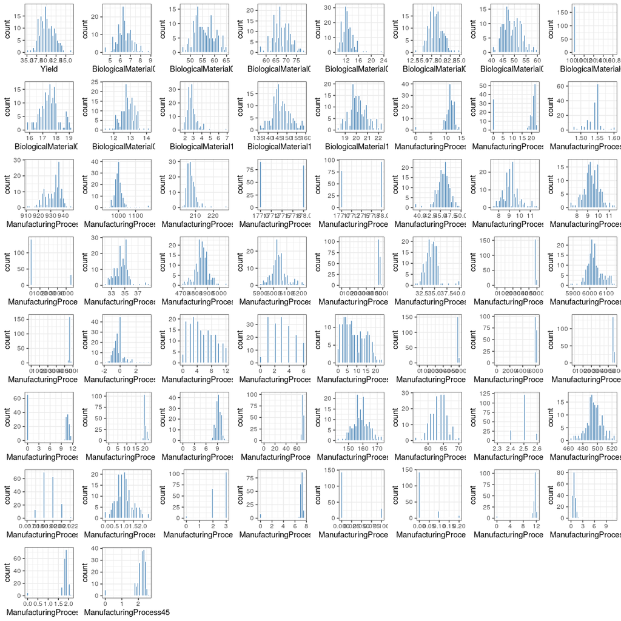

```r
bh_plot_histogram_grid(df1)
```

## Correlations

Plot the correlations between variables:

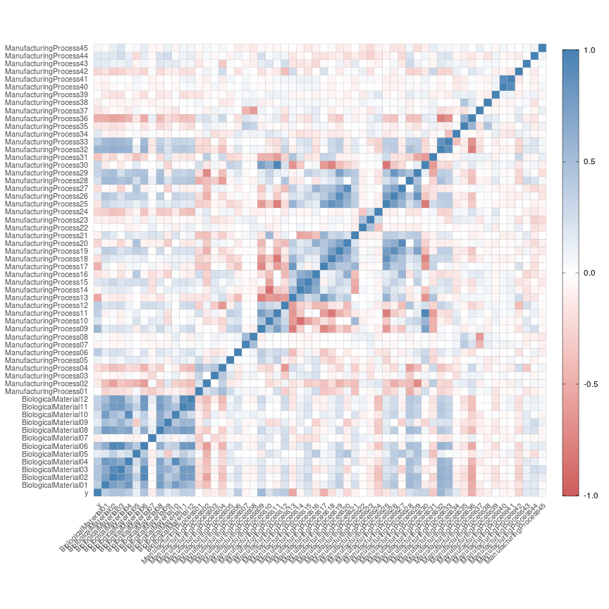

```r
correlations <- cor(df1, use = "complete.obs") # all vars are numeric
ggcorrplot(correlations,
                 colors = c("indianred", "white", "steelblue"),
           tl.cex = 8) +
  guides(fill = guide_colourbar(NULL,
                                barheight = unit(6.6, "in"),
                                ticks.colour = "black",
                                frame.colour = "black"))
```

We see that `ManufacturingProcess*` variables`9` and `32` are highly positively correlated with the response, as are the `BiologicalMaterial*` variables `2`, `3` and `6`. Likewise the variables `ManufacturingProcess13` and `ManufacturingProcess36` are highly negatively correlated with the response:

```r
response_cor <- correlations[ , 1]
data.frame(r = response_cor) %>%
  tibble::rownames_to_column("var") %>%
  arrange(r)
```

| var | r |
| --- | --- |
| ManufacturingProcess13 | -0.5475796 |
| ManufacturingProcess36 | -0.5010230 |
| ManufacturingProcess17 | -0.4898141 |
| ManufacturingProcess42 | -0.2632713 |
| ManufacturingProcess24 | -0.2481421 |
| ManufacturingProcess20 | -0.2445564 |
| ManufacturingProcess04 | -0.2149973 |
| ManufacturingProcess18 | -0.1866292 |
| ManufacturingProcess37 | -0.1711594 |
| ManufacturingProcess16 | -0.1635418 |

[output cut: 48 more lines]

## Missing data

There are 106 missing values:

```r
missing <- bh_missing_values_profile(df1)
missing$total_missing
```

```
[1] 106
```

```r
missing$total_percent_missing
```

```
[1] 1.038
```

Plot missing data:

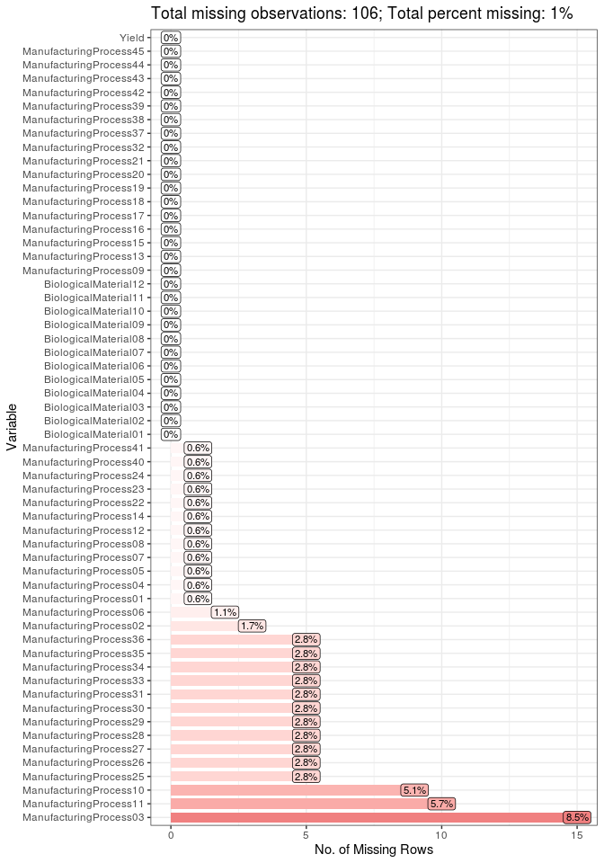

```r
bh_plot_missing(df1)
```

Top 10 variables with missing values:

```r
missing_top10_cols <- missing$n_missing %>% sort(decreasing = T) %>% head(10)
missing_top10_cols %>%
  matrix(dimnames = list(names(missing_top10_cols), "n_missing"))
```

```
                       n_missing
ManufacturingProcess03        15
ManufacturingProcess11        10
ManufacturingProcess10         9
ManufacturingProcess25         5
ManufacturingProcess26         5
ManufacturingProcess27         5
ManufacturingProcess28         5
ManufacturingProcess29         5
ManufacturingProcess30         5
ManufacturingProcess31         5
```

Top 10 rows with missing values:

```r
missing_top10_rows <- rowSums(is.na(df1)) %>% sort(decreasing = T) %>% head(10)
missing_top10_rows %>%
  matrix(dimnames = list(names(missing_top10_rows), "n_missing"))
```

```
    n_missing
1          16
172        11
173        11
174        11
175        11
176        11
23          4
2           3
3           3
4           3
```

```r
# Ref:https://stackoverflow.com/a/50919195
```

I will use imputation to remedy this missing data. The `recipes::knnimpute()` will be used in the data preprocessing step..

## Data splitting and resampling using `rsample`

In previous analyses with this data set, the observation with row no. 108 has caused issues. There are a number of zeros for this row in columns where all other rows have values greater than zero (sometimes in the thousands). This may be missing data encoded as zero, but for now I will remove this observation as it acts as an extreme outlier and has a detrimental effect on the performance.

Split the data into a training and test set, and then proceed with preprocessing and modeling.

```r
# Rename the response to `y`:
df1 <- df1 %>%
  rename(y = Yield)

# Remove the outlier point mentioned above:
df1 <- df1[-108, ]

# Split data:
set.seed(1)
splits <- initial_split(df1, prop = 0.7)
df_train <- training(splits)
df_test <- testing((splits))
```

Create folds for 10-fold cross-validation:

```r
folds <- vfold_cv(df_train, v = 10)
```

# Solution

## MARS

### Training Data

Build a MARS model and train using cross-validation.

We will preprocess the data to center and scale the predictors, impute missing values, remove near-zero variance predictors and remove highly correlated predictors (this is the same recipe as used in exercise 6.3).

```r
# Recipe:
rec1 <-
  recipe(y ~ ., data = df_train) %>%
  step_BoxCox(all_predictors()) %>%
  step_center(all_predictors()) %>%
  step_scale(all_predictors()) %>%
  step_knnimpute(all_predictors(), neighbors = 5) %>%
  step_nzv(all_predictors()) %>%
  step_corr(all_predictors(), threshold = 0.9)

# Model:
mars_mod <-
  mars(num_terms = tune(), prod_degree = tune()) %>%
  set_engine("earth") %>%
  set_mode("regression")

# Workflow:
workflow1 <-
  workflow() %>%
  add_model(spec = mars_mod) %>%
  add_recipe(recipe = rec1)

# Tuning grid:
mars_grid <- expand_grid(num_terms = 2:10, prod_degree = 1:2)

# Use `tune::tune_grid()` to combine the workflow and CV folds to fit the model on the training data:
## Read in cached results if available:
file1 <- "/home/brian/R/dir/APM/chapter7/data/mars_cv_7.5_2.RDS"
if (file.exists(file1)) {
  mars_cv <- readRDS(file1)
} else {
  mars_cv <-
    workflow1 %>%
    tune_grid(resamples = folds,
              grid = mars_grid,
              control = control_grid(save_pred = TRUE),
              metrics = metric_set(rmse, rsq))
  saveRDS(mars_cv, file1)
}
```

Plot CV results:

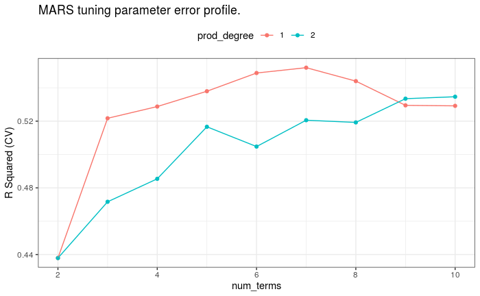

```r
mars_cv %>%
  collect_metrics() %>%
  filter(.metric == "rsq") %>%
  mutate(prod_degree = factor(prod_degree)) %>%
  ggplot(aes(num_terms, mean, color = prod_degree)) +
  geom_point() +
  geom_line() +
  labs(x = "num_terms", y = "R Squared (CV)",
       title = "MARS tuning parameter error profile.") +
  scale_x_continuous(breaks = seq(2, 10, 2)) +
  theme(legend.position = "top")
```

Select the best model and store the training $R^2$:

```r
mars_best <- mars_cv %>%
  select_best("rsq")

# Store the training R^2:
rsq_train <- mars_cv %>%
  show_best("rsq") %>%
  pluck("mean", 1)
```

### Testing Data

Fit a model using all of the training data and apply it to the test data:

```r
# Finalize the workflow by updating it to use the best model:
final_wf <-
  workflow1 %>%
  finalize_workflow(mars_best)

# This extracts the parameters in the final model (this code is clunky, could probably be made simpler):
wf <- final_wf %>% workflows::pull_workflow_spec()
num_terms <- wf$args$num_terms[2] %>% as.character()
prod_degree <- wf$args$prod_degree[2] %>% as.character()

# Fit the final model using all of the training data and evaluate using the test data:
mars_fit_final <-
  final_wf %>%
  last_fit(splits)
```

```
! train/test split: preprocessor 1/1: NA/Inf replaced by maximum positive value
```

```r
# Store test error:
rsq_test <- mars_fit_final %>%
  collect_metrics() %>%
  filter(.metric == "rsq") %>%
  pluck(".estimate")
```

Store the $R^2$ values and parameters:

```r
RSQ <- tibble(
  framework = "tidymodels",
  engine = "earth",
  model = "MARS",
  rsq_train = rsq_train,
  rsq_test = rsq_test,
  parameters = str_interp("num_terms: ${num_terms}; prod_degree: ${prod_degree}")
)
```

### Use the predictions to make diagnostic plots

Collect the predictions from the final fit and make diagnostic plots:

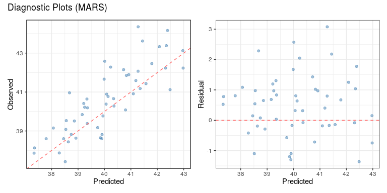

```r
preds <- mars_fit_final %>%
  collect_predictions() %>%
  mutate(residual = y - .pred)

p1 <- ggplot(preds) +
  geom_point(aes(.pred, y),
             color = "steelblue", alpha = 0.5) +
  geom_abline(color = "indianred1", linetype = "dashed") +
  labs(x = "Predicted", y = "Observed")

p2 <- ggplot(preds) +
  geom_point(aes(.pred, residual),
             color = "steelblue", alpha = 0.5) +
  geom_hline(yintercept = 0,
             color = "indianred1", linetype = "dashed") +
  labs(x = "Predicted", y = "Residual")

p1 + p2 + plot_annotation(title = "Diagnostic Plots (MARS)")
```

### Selected terms in the best MARS model

Create a MARS model from scratch on the training data using the parameters identified by CV above (there may be a more efficient way to extract the selected terms):

```r
# Update model with optimal parameters
mars_mod <- mars(num_terms = as.numeric(num_terms), prod_degree = as.numeric(prod_degree)) %>%
  set_engine("earth") %>%
  set_mode("regression")

mars_workflow <-
  workflow() %>%
  add_model(mars_mod) %>%
  add_recipe(rec1)

mars_fit <-
  mars_workflow %>%
  fit(data = df_train)
```

```
NA/Inf replaced by maximum positive valueNA/Inf replaced by maximum positive valueNA/Inf replaced by maximum positive value
```

Pull the `fit` and pass it to `summary()` so we can see the selected terms:

```r
mars_fit %>%
  pull_workflow_fit() %>%
  pluck("fit") %>%
  summary() %>%
  .$coef
```

```
                                        ..y
(Intercept)                         38.8466
h(ManufacturingProcess32--0.206354)  1.4561
h(-0.206354-ManufacturingProcess32) -1.5186
h(ManufacturingProcess09--1.02858)   0.5085
h(-1.02858-ManufacturingProcess09)  -1.1803
h(-0.655155-ManufacturingProcess33)  1.8747
h(-1.30914-ManufacturingProcess13)   1.7041
```

## SVM with polynomial kernel

### Training Data

Build an SVM with a polynomial kernel and train using cross-validation.

I will use the same preprocessing as the MARS model.

```r
# Model:
svm_poly_mod <-
  svm_poly(cost = tune(), degree = tune(), scale_factor = tune()) %>% # leave `margin` (0.1) as the default
  set_engine("kernlab") %>%
  set_mode("regression")

# Workflow:
workflow2 <-
  workflow() %>%
  add_model(spec = svm_poly_mod) %>%
  add_recipe(recipe = rec1)

# Tuning grid:
svm_poly_grid <- expand_grid(cost = c(0.01, 0.05, 0.1),
                             degree = 1:2,
                             scale_factor = c(0.25, 0.5, 1))

# Use `tune::tune_grid()` to combine the workflow and CV folds to fit the model on the training data:
## Read in cached results if available:
file1 <- "/home/brian/R/dir/APM/chapter7/data/svm_poly_cv_7.5_2.RDS"
if (file.exists(file1)) {
  svm_poly_cv <- readRDS(file1)
} else {
  svm_poly_cv <-
    workflow2 %>%
    tune_grid(resamples = folds,
              grid = svm_poly_grid,
              control = control_grid(save_pred = TRUE),
              metrics = metric_set(rmse, rsq))
  saveRDS(svm_poly_cv, file1)
}
```

Plot CV results:

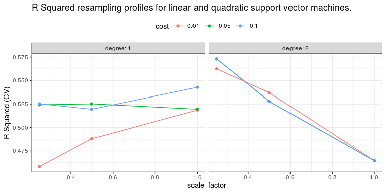

```r
svm_poly_cv %>%
  collect_metrics() %>%
  filter(.metric == "rsq") %>%
  mutate(cost = factor(cost),
         degree = factor(degree)) %>%
  ggplot(aes(scale_factor, mean, group = cost, color = cost)) +
  geom_point() +
  geom_line() +
  labs(x = "scale_factor", y = "R Squared (CV)",
       title = "R Squared resampling profiles for linear and quadratic support vector machines.") +
  facet_wrap(~degree, labeller = label_both) +
  theme(legend.position = "top")
```

Select the best model and store the training $R^2$:

```r
svm_poly_best <- svm_poly_cv %>%
  select_best("rsq")

# Store the training R^2:
rsq_train <- svm_poly_cv %>%
  show_best("rsq") %>%
  pluck("mean", 1)
```

### Testing Data

Fit a model using all of the training data and apply it to the test data:

```r
# Finalize the workflow by updating it to use the best model:
final_wf <-
  workflow2 %>%
  finalize_workflow(svm_poly_best)

# This extracts the parameters in the final model (this code is clunky, could probably be made simpler):
wf <- final_wf %>% workflows::pull_workflow_spec()
cost <- wf$args$cost[2] %>% as.character()
degree <- wf$args$degree[2] %>% as.character()
scale_factor <- wf$args$scale_factor[2] %>% as.character()

# Fit the final model using all of the training data and evaluate using the test data:
svm_poly_fit_final <-
  final_wf %>%
  last_fit(splits)
```

```
! train/test split: preprocessor 1/1: NA/Inf replaced by maximum positive value
```

```r
# Store test error:
rsq_test <- svm_poly_fit_final %>%
  collect_metrics() %>%
  filter(.metric == "rsq") %>%
  pluck(".estimate")
```

Store the $R^2$ values and parameters:

```r
RSQ <- rbind(RSQ,
                 c(framework = "tidymodels",
                   engine = "kernlab",
                   model = "SVM (Polynomial)",
                   rsq_train = rsq_train,
                   rsq_test = rsq_test,
                   parameters = str_interp("cost: ${cost}; degree: ${degree}; scale_factor: ${scale_factor}")))
```

### Use the predictions to make diagnostic plots

Collect the predictions from the final fit and make diagnostic plots:

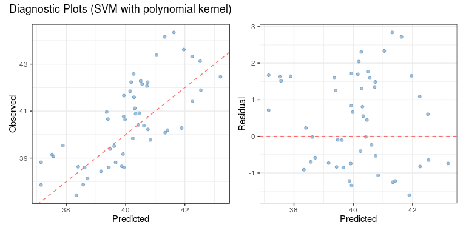

```r
preds <- svm_poly_fit_final %>%
  collect_predictions() %>%
  mutate(residual = y - .pred)

p3 <- ggplot(preds) +
  geom_point(aes(.pred, y),
             color = "steelblue", alpha = 0.5) +
  geom_abline(color = "indianred1", linetype = "dashed") +
  labs(x = "Predicted", y = "Observed")

p4 <- ggplot(preds) +
  geom_point(aes(.pred, residual),
             color = "steelblue", alpha = 0.5) +
  geom_hline(yintercept = 0,
             color = "indianred1", linetype = "dashed") +
  labs(x = "Predicted", y = "Residual")

p3 + p4 + plot_annotation(title = "Diagnostic Plots (SVM with polynomial kernel)")
```

## Metrics

Compare the performance of the non-linear models in this exercise to the linear model (PLS) from exercise 6.3:

```r
RSQ_linear <- readRDS("/home/brian/R/dir/APM/chapter7/data/APM_7_exercise_6_3_RSQ.RDS")
rbind(RSQ, RSQ_linear) %>%
  mutate(rsq_train = round(as.numeric(rsq_train), 3),
         rsq_test = round(as.numeric(rsq_test), 3)) %>%
  arrange(-rsq_test)
```

| framework | engine | model | rsq_train | rsq_test | parameters |
| --- | --- | --- | --- | --- | --- |
| tidymodels | earth | MARS | 0.552 | 0.679 | num_terms: 7; prod_degree: 1 |
| tidymodels | mixOmics | PLS 2 | 0.558 | 0.592 | num_comp: 4 |
| tidymodels | kernlab | SVM (Polynomial) | 0.573 | 0.529 | cost: 0.1; degree: 2; scale_factor: 0.25 |
| tidymodels | mixOmics | PLS 1 | 0.603 | 0.436 | num_comp: 4 |

## Plot the relationship between important predictors and response

*Use the same code as in exercise 6.3 to plot the relationship of these predictors with the response.*

Use `prep()` and `bake()` to apply the preprocessing recipe to ALL of the data before making the plots:

```r
df_pp <- rec1 %>% # rec1 for the MARS model
  prep() %>%
  bake(df1) %>%
  cbind(df1$y)
```

```
NA/Inf replaced by maximum positive valueNA/Inf replaced by maximum positive valueNA/Inf replaced by maximum positive value
```

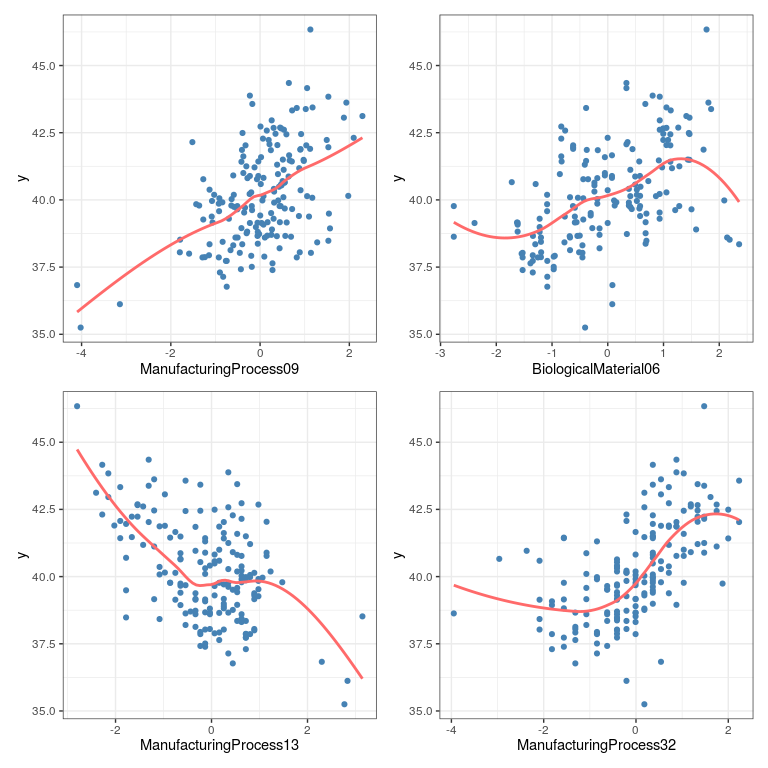

```r
p1 <- ggplot(df_pp, aes(ManufacturingProcess09, y)) +
  geom_point(color = "steelblue") +
  geom_smooth(se = F, color = "indianred1")

p2 <- ggplot(df_pp, aes(BiologicalMaterial06, y)) +
  geom_point(color = "steelblue") +
  geom_smooth(se = F, color = "indianred1")

p3 <- ggplot(df_pp, aes(ManufacturingProcess13, y)) +
  geom_point(color = "steelblue") +
  geom_smooth(se = F, color = "indianred1")

p4 <- ggplot(df_pp, aes(ManufacturingProcess32, y)) +
  geom_point(color = "steelblue") +
  geom_smooth(se = F, color = "indianred1")

(p1 + p2) / (p3 + p4)
```

`ManufacturingProcess09`, `BiologicalMaterial06` and `ManufacturingProcess32` have a positive relationship with the response. `ManufacturingProcess13` has a negative relationship. If these manufacturing processes can be controlled, then altering these steps in the process to have higher (or lower) values could improve the overall Yield of the process. A statistically designed experiment could be used to investigate a causal relationship between the settings of these processes and the overall yield.

`ManufacturingProcess09` seems to have the most linear relationship, while the others are clearly non-linear.

[^1]: Kuhn M, Johnson K (2013). *Applied Predictive Modeling*. Springer.